# Analyzing Individual BGG Users

Phil Henrickson

2022-01-01

# **yayitsk’s** BoardGameGeek Collection

This notebook contains a set of analyses for the selected user’s boardgamegeek collection. The bulk of the analysis is focused on building a user-specific predictive model to predict the games that yayitsk is likely to own. This enables to ask questions like, based on the games the user currently owns, what games are a good fit for their collection? What upcoming games are they likely to purchase?

This analysis is based on data from BoardGameGeek that was last updated on **2021-12-20.**

# 1 Collection Overview

We can look at a basic description of the number of games that the user owns, has rated, has previously owned, etc.

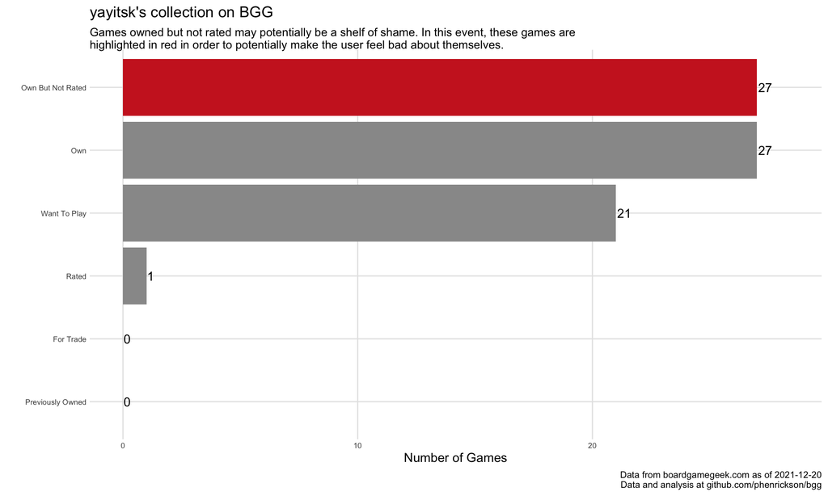

What years has the user owned/rated games from? While we can’t see when a user added or removed a game from their collection, we can look at their collection by the years in which their games were published.

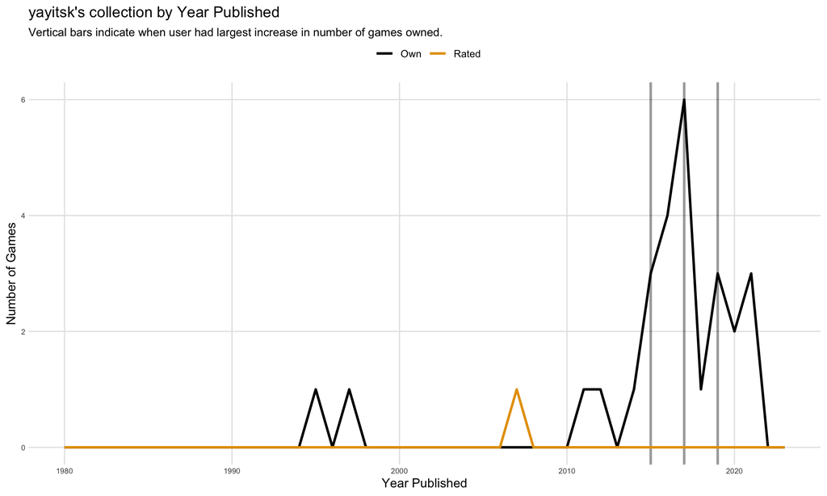

## 1.1 What types of games does yayitsk own?

We can look at the most frequent types of categories, mechanics, designers, and artists that appear in a user’s collection.

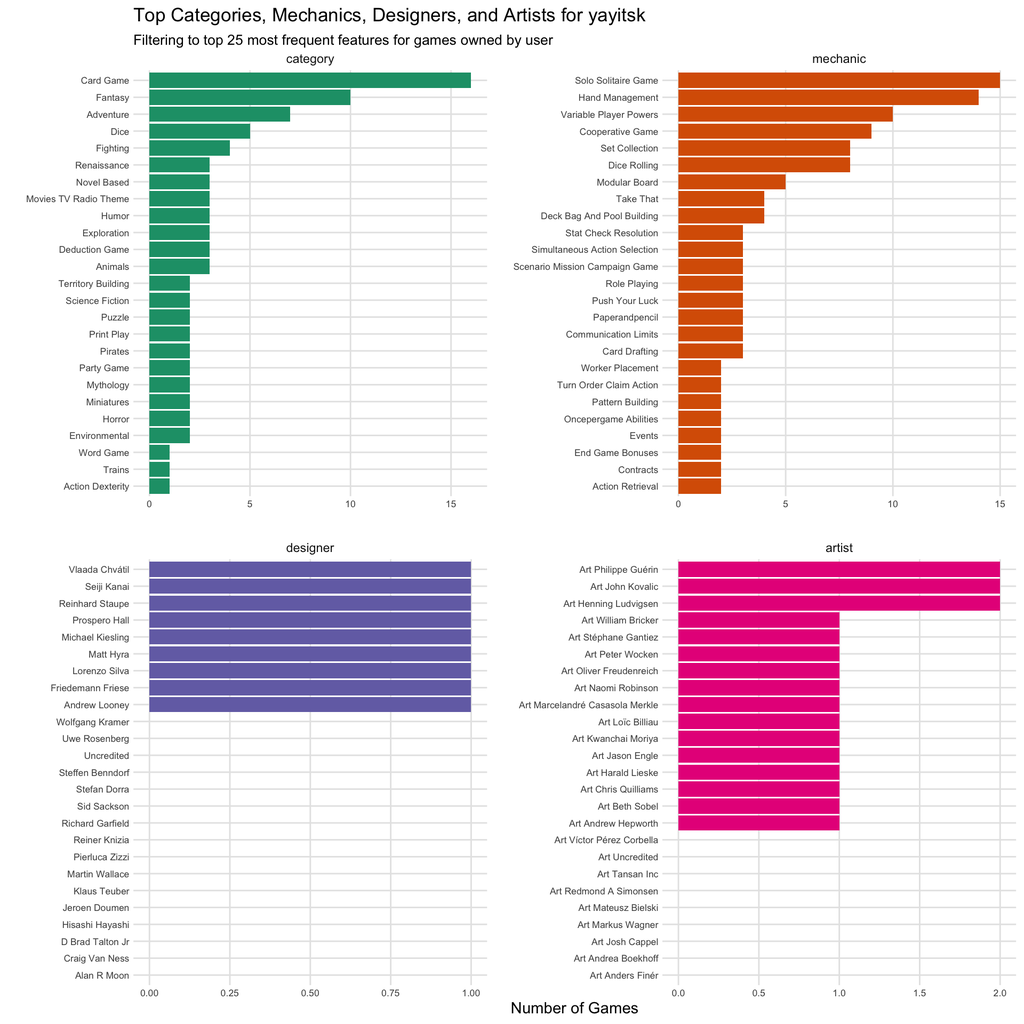

# 2 Modeling **yayitsk’s** Collection

| username | dataset | period | games_owned | games_rated | games_played |
| --- | --- | --- | --- | --- | --- |
| yayitsk | training | published before 2020 | 21 | 1 | 22 |
| yayitsk | test | published 2020 or later | 5 | 0 | 5 |

There are two main (binary) outcomes we will be modeling for the user.

The first, **own** refers to whether the user currently lists a game as owned in their collection. The second, **played** refers to whether the user currently owns, has rated, or previously owned a game. This means the latter will generally have a larger list of games, but may still be a useful category to examine for people who play lots of games without necessarily owning them.

We will train predictive models to learn the probability that the user will own or play individual games based on their features.

## 2.1 Coefficients for yayitsk

We can examine coefficients from the trained modes, which are penalized logistic regressions fit to our two main outcomes. Positive values indicate that a feature increases a user’s probabilility of owning/rating a game, while negative values indicate a feature decreases the probability.

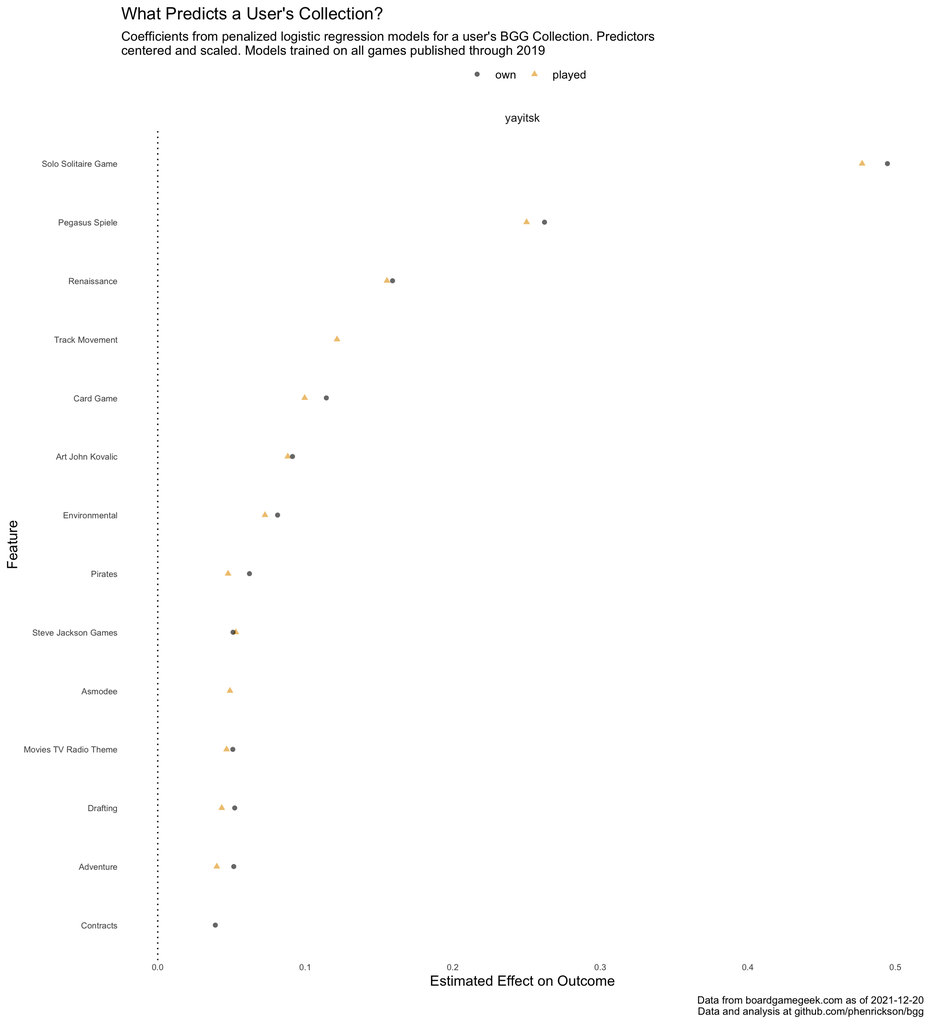

## 2.2 Visualizing Predictors for yayitsk’s Collection

Why did the model identify these features? We can make density plots of the important features for predicting whether the user owned a game. Blue indicates the density for games owned by the user, while grey indicates the density for games not owned by the user.

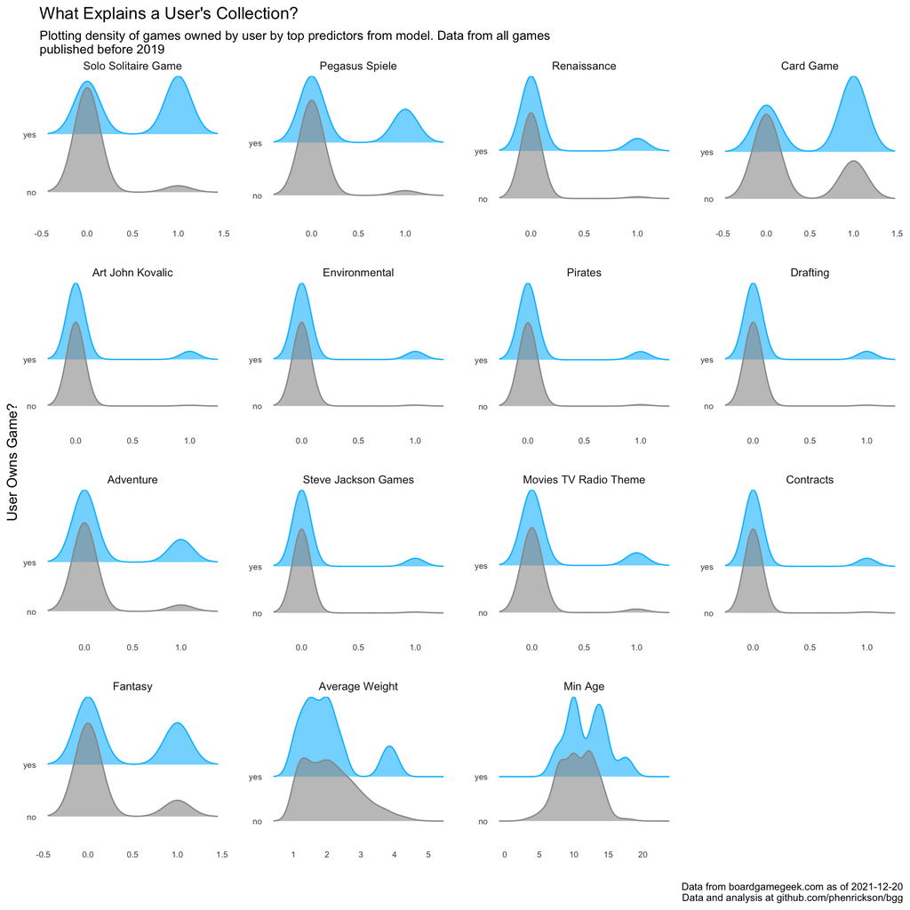

Binary predictors can be difficult to see with this visualization, so we can also directly examine the percentage of games in a user’s collection with a predictor vs the percentage of all games with that predictor.

| username | Feature | % of Games with Feature In_Collection | % of Games with Feature All_Games | Ratio |
| --- | --- | --- | --- | --- |
| yayitsk | Contracts | 9.5% | 1.0% | 9.3 |
| yayitsk | Drafting | 9.5% | 1.0% | 9.2 |
| yayitsk | Solo Solitaire Game | 52.4% | 5.8% | 9.0 |
| yayitsk | Steve Jackson Games | 9.5% | 1.1% | 8.9 |
| yayitsk | Environmental | 9.5% | 1.1% | 8.6 |
| yayitsk | Renaissance | 14.3% | 2.0% | 7.3 |
| yayitsk | Pegasus Spiele | 33.3% | 4.7% | 7.1 |
| yayitsk | Pirates | 9.5% | 1.7% | 5.5 |
| yayitsk | Movies TV Radio Theme | 14.3% | 3.9% | 3.7 |
| yayitsk | Adventure | 23.8% | 6.6% | 3.6 |
| yayitsk | Puzzle | 9.5% | 3.4% | 2.8 |
| yayitsk | Word Game | 4.8% | 1.8% | 2.7 |
| yayitsk | Fantasy | 38.1% | 14.8% | 2.6 |
| yayitsk | Card Game | 61.9% | 31.0% | 2.0 |
| yayitsk | Horror | 4.8% | 4.0% | 1.2 |
| yayitsk | Party Game | 9.5% | 8.5% | 1.1 |
| yayitsk | Action Dexterity | 4.8% | 4.8% | 1.0 |
| yayitsk | Medieval | 4.8% | 6.3% | 0.8 |
| yayitsk | Negotiation | 0.0% | 3.7% | 0.0 |
| yayitsk | Trivia | 0.0% | 1.8% | 0.0 |
| yayitsk | City Building | 0.0% | 4.3% | 0.0 |
| yayitsk | Racing | 0.0% | 2.8% | 0.0 |
| yayitsk | Mafia | 0.0% | 0.7% | 0.0 |
| yayitsk | Trains | 0.0% | 2.2% | 0.0 |
| yayitsk | Prehistoric | 0.0% | 1.0% | 0.0 |

# 3 Assess Model’s Performance on Training Set

Before predicting games in upcoming years, we can examine how well the model did and what games it liked in the training set. In this case, we used resampling techniques (cross validation) to ensure that the model had not seen a game before making its predictions.

## 3.1 Separation Plot

An easy way to examine the performance of classification model is to view a separation plot. We plot the predicted probabilities from the model for every game (from resampling) from lowest to highest. We then overlay a blue line for any game that the user does own. A good classifier is one that is able to *separate* the blue (games owned by the user) from the white (games not owned by the user), with most of the blue occurring at the highest probabilities (right side of the chart).

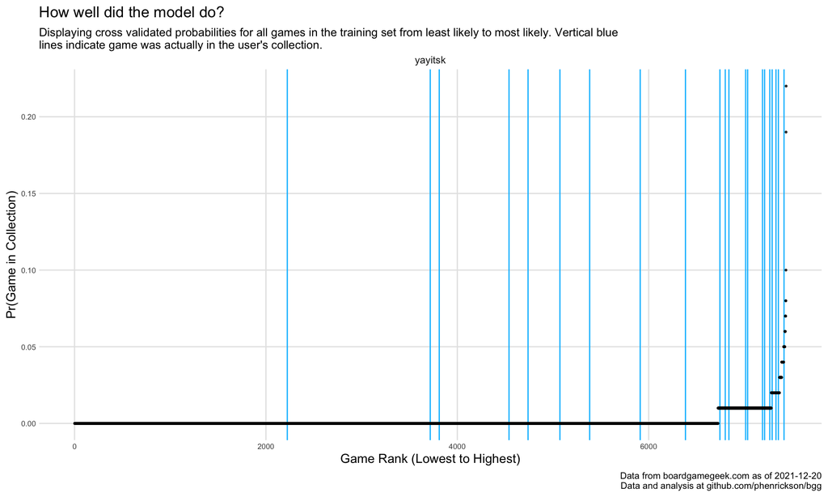

## 3.2 Top Games for **yayitsk** from Training Set

We can display this information in table form, displaying the 100 games with the highest probability of ownership, adding a blue line when the user does own the game.

| username | yearpublished | game_id | name | pred_played | pred_own | actual_played | actual_own |
| --- | --- | --- | --- | --- | --- | --- | --- |
| yayitsk | 2014 | 154203 | Imperial Settlers | 0.03 | 0.22 | 0 | 0 |
| yayitsk | 2019 | 283863 | The Magnificent | 0.26 | 0.19 | 0 | 0 |
| yayitsk | 2016 | 167791 | Terraforming Mars | 0.02 | 0.10 | 0 | 0 |
| yayitsk | 2019 | 251247 | Barrage | 0.04 | 0.08 | 0 | 0 |
| yayitsk | 2019 | 253635 | Ragusa | 0.05 | 0.08 | 0 | 0 |
| yayitsk | 2016 | 191189 | Aeon's End | 0.04 | 0.07 | 0 | 0 |
| yayitsk | 2018 | 247763 | Underwater Cities | 0.05 | 0.07 | 0 | 0 |
| yayitsk | 2009 | 39683 | At the Gates of Loyang | 0.06 | 0.07 | 0 | 0 |
| yayitsk | 2014 | 156009 | Port Royal | 0.05 | 0.07 | 0 | 0 |
| yayitsk | 2015 | 143405 | Sylvion | 0.03 | 0.06 | 0 | 0 |
| yayitsk | 2019 | 284825 | Florenza Dice Game | 0.05 | 0.06 | 0 | 0 |
| yayitsk | 1991 | 235 | Blackbeard | 0.05 | 0.06 | 0 | 0 |
| yayitsk | 2018 | 250442 | Crypt | 0.06 | 0.06 | 0 | 0 |
| yayitsk | 2016 | 72321 | The Networks | 0.04 | 0.06 | 0 | 0 |
| yayitsk | 2008 | 37380 | Roll Through the Ages: The Bronze Age | 0.04 | 0.05 | 0 | 0 |
| yayitsk | 2019 | 237023 | Era of Kingdoms | 0.04 | 0.05 | 0 | 0 |
| yayitsk | 2013 | 140612 | The Hobbit: An Unexpected Journey | 0.04 | 0.05 | 0 | 0 |
| yayitsk | 2017 | 162886 | Spirit Island | 0.07 | 0.05 | 1 | 1 |
| yayitsk | 2019 | 264220 | Tainted Grail: The Fall of Avalon | 0.04 | 0.05 | 0 | 0 |
| yayitsk | 2019 | 276025 | Maracaibo | 0.17 | 0.05 | 0 | 0 |
| yayitsk | 2018 | 224904 | Sunset Over Water | 0.02 | 0.05 | 0 | 0 |
| yayitsk | 2017 | 209778 | Magic Maze | 0.08 | 0.05 | 0 | 0 |
| yayitsk | 2019 | 265736 | Tiny Towns | 0.04 | 0.05 | 0 | 0 |
| yayitsk | 1993 | 4102 | Europa Universalis | 0.04 | 0.05 | 0 | 0 |
| yayitsk | 2016 | 126100 | Mythos Tales | 0.04 | 0.05 | 0 | 0 |
| yayitsk | 2016 | 195296 | Scuttle! | 0.04 | 0.05 | 0 | 0 |
| yayitsk | 2016 | 191387 | Star Trek: The Dice Game | 0.03 | 0.04 | 0 | 0 |
| yayitsk | 2017 | 231218 | Black Sonata | 0.04 | 0.04 | 0 | 0 |
| yayitsk | 2008 | 29678 | Munchkin Quest | 0.03 | 0.04 | 0 | 0 |
| yayitsk | 2018 | 199792 | Everdell | 0.04 | 0.04 | 0 | 0 |

[output cut: 70 more lines]

We can also more formally assess how well the model did in resampling by looking at the area under the receiver operating characteristic. A perfect model would receive a score of 1, while a model that cannot predict the outcome will default to a score of 0.5. The extent to which something is a *good* score depends on the setting, but generally anything in the .8 to .9 range is very good while the .7 to .8 range is perfectly acceptable.

| username | outcome_type | .metric | .estimator | .estimate |
| --- | --- | --- | --- | --- |
| yayitsk | own | roc_auc | binary | 0.845 |
| yayitsk | played | roc_auc | binary | 0.794 |

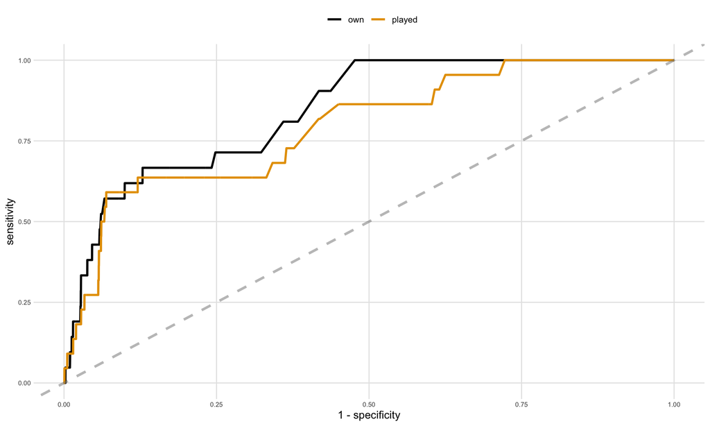

Another way to think about the model performance is to view its lift, or its ability to detect the positive outcomes over that of a null model. High lift indicates the model can much more quickly find all of the positive outcomes (in this case, games owned or played by the user), while a model with no lift is no better than random guessing.

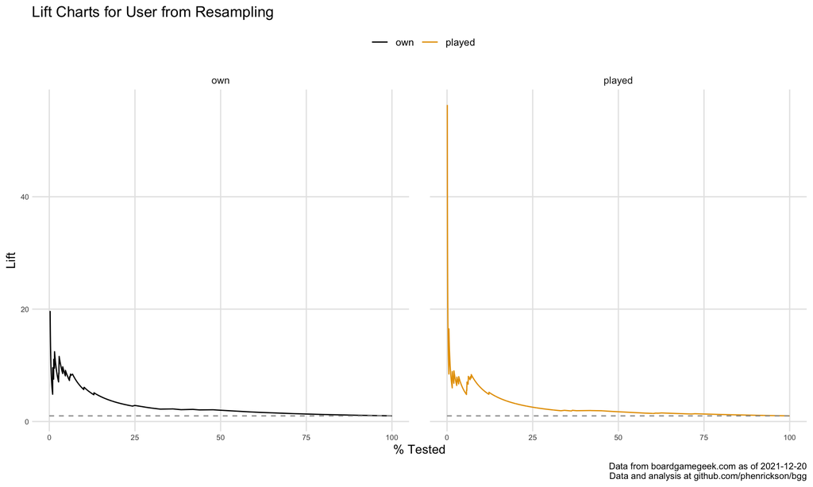

## 3.3 Most and Least Likely Games

What games does the model think yayitsk is **most likely to own** that are **not** in their collection?

| username | yearpublished | game_id | name | pred_own | actual_own |
| --- | --- | --- | --- | --- | --- |
| yayitsk | 2014 | 154203 | Imperial Settlers | 0.22 | 0 |
| yayitsk | 2019 | 283863 | The Magnificent | 0.19 | 0 |
| yayitsk | 2016 | 167791 | Terraforming Mars | 0.10 | 0 |
| yayitsk | 2019 | 251247 | Barrage | 0.08 | 0 |
| yayitsk | 2019 | 253635 | Ragusa | 0.08 | 0 |

What games does the model think yayitsk is **least likely to own** that **are** in their collection?

| username | yearpublished | game_id | name | pred_own | actual_own |
| --- | --- | --- | --- | --- | --- |
| yayitsk | 2017 | 230802 | Azul | 0 | 1 |
| yayitsk | 2015 | 178900 | Codenames | 0 | 1 |
| yayitsk | 1995 | 1197 | Blink | 0 | 1 |
| yayitsk | 2018 | 256382 | Disney Villainous | 0 | 1 |
| yayitsk | 1997 | 258 | Fluxx | 0 | 1 |

## 3.4 Top Games by Year

Top 25 games most likely to be owned by the user in each year, highlighting in blue the games that the user has owned/played.

| rank | 2011 | 2012 | 2013 | 2014 | 2015 | 2016 | 2017 | 2018 | 2019 |
| --- | --- | --- | --- | --- | --- | --- | --- | --- | --- |
| 1 | Takenoko | Ginkgopolis | The Hobbit: An Unexpected Journey | Imperial Settlers | Sylvion | Terraforming Mars | Spirit Island | Underwater Cities | The Magnificent |
| 2 | Mondo | Robinson Crusoe: Adventures on the Cursed Island | Legacy: The Testament of Duke de Crecy | Port Royal | Smash Up: Munchkin | Aeon's End | Magic Maze | Crypt | Barrage |
| 3 | Mage Knight Board Game | Munchkin Apocalypse | Munchkin Pathfinder | Roll Through the Ages: The Iron Age | The Pursuit of Happiness | The Networks | Black Sonata | Sunset Over Water | Ragusa |
| 4 | Elder Sign | Munchkin Conan | Munchkin Legends | Pandemic: The Cure | Shakespeare | Mythos Tales | Raging Bulls | Everdell | Florenza Dice Game |
| 5 | Sentinels of the Multiverse | CO₂ | Pathfinder Adventure Card Game: Rise of the Runelords – Base Set | Legendary Encounters: An Alien Deck Building Game | Thunderbirds | Scuttle! | Pocket Mars | Architects of the West Kingdom | Era of Kingdoms |
| 6 | Space Infantry | Nuklear Winter '68 | Sail to India | Onirim (Second Edition) | The Bloody Inn | Star Trek: The Dice Game | A4 Quest | Too Many Bones: Undertow | Tainted Grail: The Fall of Avalon |
| 7 | Drako: Dragon & Dwarves | Pixel Tactics | Dungeon Roll | Elevenses for One | Warhammer Quest: The Adventure Card Game | Agricola (Revised Edition) | D100 Dungeon | 1066, Tears to Many Mothers | Maracaibo |
| 8 | BraveRats | Urbion | Eldritch Horror | Machina Arcana | Viticulture Essential Edition | Legendary Encounters: A Firefly Deck Building Game | Twin Stars: Adventure Series I | Palm Island | Tiny Towns |
| 9 | Field Commander: Napoleon | Thunderbolt Apache Leader | BattleCON: Devastation of Indines | Nations: The Dice Game | The Game | Mr. Cabbagehead's Garden | First Martians: Adventures on the Red Planet | Bargain Basement Bathysphere | Bios: Origins (Second Edition) |
| 10 | Friday | In Magnificent Style: Pickett's Charge at Gettysburg | Forbidden Desert | Smash Up: Science Fiction Double Feature | FUSE | 1572: The Lost Expedition | XenoShyft: Dreadmire | Crown of Emara | Trails of Tucana |
| 11 | Martian Dice | Serenissima (Second Edition) | SOS Titanic | Fields of Arle | Smash Up: Pretty Pretty Smash Up | Pentaquark | Sagrada | Dark Souls: The Card Game | It's a Wonderful World |
| 12 | Village | Andean Abyss | Smash Up: The Obligatory Cthulhu Set | Fleet Commander: Nimitz – The WWII Pacific Ocean Solitaire Strategy Game | Castellion | Inis | Ex Libris | Blackout: Hong Kong | Herbaceous Sprouts |
| 13 | Gears of War: The Board Game | Seasons | Hoplomachus: Rise of Rome | Sherlock Holmes: Four Investigations | Hoplomachus: Origins | Aventuria: Adventure Card Game | Gloomhaven | Cosmic Run: Regeneration | Amul |
| 14 | Eminent Domain | Il Vecchio | Navajo Wars | Hapsburg Eclipse | Bottom of the 9th | Hit Z Road | Herbaceous | Solenia | TINYforming Mars |
| 15 | Munchkin Zombies | Level 7 [Escape] | The Hunters: German U-Boats at War, 1939-43 | Pathfinder Adventure Card Game: Skull & Shackles – Base Set | Tides of Time | Star Trek: Frontiers | Memoarrr! | Walking in Burano | Aerion |
| 16 | Flash Point: Fire Rescue | Pirates of the Spanish Main: Shuffling the Deck | Dawn of the Zeds (Second edition) | Fire in the Lake | Enemy Action: Ardennes | Bandido | Deckscape: The Fate of London | That's Pretty Clever! | Fire! |
| 17 | Pictomania | Freedom: The Underground Railroad | Cruel Necessity: The English Civil Wars 1640-1653 | Grog Island | Agent Decker | Expedition: The Roleplaying Card Game | This War of Mine: The Board Game | Welcome To... | Iron Helm |
| 18 | Star Trek Deck Building Game: The Next Generation | Puzzle Strike (Third Edition) | Infection: Humanity's Last Gasp | DungeonQuest Revised Edition | Airborne Commander | The Oregon Trail Card Game | 13 Minutes: The Cuban Missile Crisis, 1962 | Detective: A Modern Crime Board Game | SpaceShipped |
| 19 | Dungeons & Dragons: Wrath of Ashardalon Board Game | Love Letter | Maquis | Assault on Doomrock | Deep Space D-6 | Silent Victory: U.S. Submarines in the Pacific, 1941-45 | Smash Up: Big in Japan | Nightfighter Ace: Air Defense Over Germany, 1943-44 | Choose Your Own Adventure: War with the Evil Power Master |
| 20 | Dungeons & Dragons: The Legend of Drizzt Board Game | Hoplomachus: The Lost Cities | Theseus: The Dark Orbit | Run, Fight, or Die! | Coffee Roaster | Smash Up: It's Your Fault! | One Deck Dungeon: Forest of Shadows | Skies Above the Reich | The Isle of Cats |
| 21 | Strasbourg | The Big Bang Theory: The Party Game | Cuba Libre | VivaJava: The Coffee Game: The Dice Game | Hostage Negotiator | Mini Rogue: A 9-Card Print-and-Play Game | Colonial Twilight: The French-Algerian War, 1954-62 | Dual Powers: Revolution 1917 | Yukon Airways |
| 22 | Thunderstone: Dragonspire | Cthulhu Fluxx | Bruges | Splendor | The Maiden in the Forest | 13 Days: The Cuban Missile Crisis | Target for Today | Haven | Set a Watch |
| 23 | City Tycoon | New Amsterdam | Wunderland | Sheep & Thief | Rolling America | One Deck Dungeon | Sherman Leader | Smash Up: Oops, You Did It Again | Middara: Unintentional Malum – Act 1 |
| 24 | Band of Brothers: Screaming Eagles | The Cave | Firefly: The Game | Roll Through the Ages: The Iron Age with Mediterranean Expansion | Haspelknecht | Nautilion | Finished! | Goblivion | Era: Medieval Age |
| 25 | A Few Acres of Snow | Legendary: A Marvel Deck Building Game | Gravwell: Escape from the 9th Dimension | Doodle Quest | Burgle Bros. | Tides of Madness | Hostage Negotiator: Crime Wave | Hitler's Reich: WW2 in Europe | Aquatica |

## 3.5 Interactive Predictions from Resampling

Interactive table for predictions from resampling.

|  | username | yearpublished | rank | game_id | name | pred_played | pred_own | actual_played | actual_own |
| --- | --- | --- | --- | --- | --- | --- | --- | --- | --- |
| 1 | yayitsk | 1900 | 275 | 10400 | Patience | 0.01 | 0.01 | 0 | 0 |
| 2 | yayitsk | 1900 | 541 | 15878 | Rummy | 0.01 | 0.01 | 0 | 0 |
| 3 | yayitsk | 1900 | 727 | 5546 | Marbles | 0 | 0 | 0 | 0 |
| 4 | yayitsk | 1900 | 730 | 11901 | Tic-Tac-Toe | 0 | 0 | 0 | 0 |
| 5 | yayitsk | 1900 | 779 | 188 | Go | 0 | 0 | 0 | 0 |
| 6 | yayitsk | 1900 | 887 | 171 | Chess | 0 | 0 | 0 | 0 |
| 7 | yayitsk | 1900 | 898 | 2065 | Shogi | 0 | 0 | 0 | 0 |
| 8 | yayitsk | 1900 | 900 | 2393 | Xiangqi | 0 | 0 | 0 | 0 |
| 9 | yayitsk | 1900 | 1122 | 26952 | International Checkers | 0 | 0 | 0 | 0 |
| 10 | yayitsk | 1900 | 1159 | 1602 | The Royal Game of Ur | 0 | 0 | 0 | 0 |

[output cut: 7426 more lines]

# 4 Validating the Model on 2020

How well did a model trained on a user’s collection through 2019 perform in predicting games for the user from 2020?

| username | outcome_type | yearpublished | .metric | .estimator | .estimate |
| --- | --- | --- | --- | --- | --- |
| yayitsk | own | 2020 | roc_auc | binary | 0.902 |
| yayitsk | played | 2020 | roc_auc | binary | 0.926 |

Table of top 25 games from 2020, highlighting games that the user owns.

| username | yearpublished | game_id | name | pred_own | pred_played | actual_own | actual_played |
| --- | --- | --- | --- | --- | --- | --- | --- |
| yayitsk | 2020 | 298130 | Amalfi | 0.05 | 0.05 | 0 | 0 |
| yayitsk | 2020 | 260645 | 1565: St. Elmo's Pay – The Great Siege of Malta | 0.04 | 0.04 | 0 | 0 |
| yayitsk | 2020 | 293531 | Detective: A Modern Crime Board Game – Season One | 0.04 | 0.03 | 0 | 0 |
| yayitsk | 2020 | 302524 | Super-Skill Pinball: 4-Cade | 0.04 | 0.03 | 0 | 0 |
| yayitsk | 2020 | 304420 | Bonfire | 0.04 | 0.04 | 0 | 0 |
| yayitsk | 2020 | 318977 | MicroMacro: Crime City | 0.04 | 0.03 | 0 | 0 |
| yayitsk | 2020 | 184267 | On Mars | 0.03 | 0.02 | 0 | 0 |
| yayitsk | 2020 | 267243 | The Conquistadors: The Spanish Conquest of the Americas 1518-1548 | 0.03 | 0.03 | 0 | 0 |
| yayitsk | 2020 | 291511 | Medici: The Dice Game | 0.03 | 0.03 | 0 | 0 |
| yayitsk | 2020 | 220133 | Endangered | 0.02 | 0.02 | 0 | 0 |
| yayitsk | 2020 | 237860 | The Shores of Tripoli | 0.02 | 0.02 | 0 | 0 |
| yayitsk | 2020 | 252153 | Tang Garden | 0.02 | 0.02 | 0 | 0 |
| yayitsk | 2020 | 262274 | D6: Dungeons, Dudes, Dames, Danger, Dice and Dragons! | 0.02 | 0.01 | 0 | 0 |
| yayitsk | 2020 | 270143 | Kōhaku | 0.02 | 0.02 | 0 | 0 |
| yayitsk | 2020 | 281075 | Welcome to New Las Vegas | 0.02 | 0.01 | 0 | 0 |
| yayitsk | 2020 | 282081 | The Zorro Dice Game | 0.02 | 0.02 | 0 | 0 |
| yayitsk | 2020 | 282246 | Camp Pinetop | 0.02 | 0.02 | 0 | 0 |
| yayitsk | 2020 | 284742 | Honey Buzz | 0.02 | 0.01 | 0 | 0 |
| yayitsk | 2020 | 291508 | Tiny Epic Dinosaurs | 0.02 | 0.01 | 0 | 0 |
| yayitsk | 2020 | 293309 | Kraken Attack! | 0.02 | 0.02 | 0 | 0 |
| yayitsk | 2020 | 296605 | Adventure of D (Second Edition) | 0.02 | 0.02 | 0 | 0 |
| yayitsk | 2020 | 300322 | Hallertau | 0.02 | 0.01 | 0 | 0 |
| yayitsk | 2020 | 301880 | Raiders of Scythia | 0.02 | 0.01 | 0 | 0 |
| yayitsk | 2020 | 304728 | SpongeBob SquarePants: Plankton Rising | 0.02 | 0.02 | 0 | 0 |
| yayitsk | 2020 | 306040 | Merv: The Heart of the Silk Road | 0.02 | 0.05 | 0 | 0 |

# 5 Predicting Upcoming Games (2020 and On) for **yayitsk**

Examine the top games for the test set.

| username | yearpublished | game_id | name | rank | own | played |
| --- | --- | --- | --- | --- | --- | --- |
| yayitsk | 2020 | 298130 | Amalfi | 1 | 0.05 | 0.05 |
| yayitsk | 2020 | 293531 | Detective: A Modern Crime Board Game – Season One | 2 | 0.04 | 0.03 |
| yayitsk | 2020 | 302524 | Super-Skill Pinball: 4-Cade | 3 | 0.04 | 0.03 |
| yayitsk | 2020 | 318977 | MicroMacro: Crime City | 4 | 0.04 | 0.03 |
| yayitsk | 2020 | 304420 | Bonfire | 5 | 0.04 | 0.04 |
| yayitsk | 2020 | 260645 | 1565: St. Elmo's Pay – The Great Siege of Malta | 6 | 0.04 | 0.04 |
| yayitsk | 2020 | 184267 | On Mars | 7 | 0.03 | 0.02 |
| yayitsk | 2020 | 267243 | The Conquistadors: The Spanish Conquest of the Americas 1518-1548 | 8 | 0.03 | 0.03 |
| yayitsk | 2020 | 291511 | Medici: The Dice Game | 9 | 0.03 | 0.03 |
| yayitsk | 2020 | 281075 | Welcome to New Las Vegas | 10 | 0.02 | 0.01 |
| yayitsk | 2020 | 284742 | Honey Buzz | 11 | 0.02 | 0.01 |
| yayitsk | 2020 | 300322 | Hallertau | 12 | 0.02 | 0.01 |
| yayitsk | 2020 | 301880 | Raiders of Scythia | 13 | 0.02 | 0.01 |
| yayitsk | 2020 | 306040 | Merv: The Heart of the Silk Road | 14 | 0.02 | 0.05 |
| yayitsk | 2020 | 262274 | D6: Dungeons, Dudes, Dames, Danger, Dice and Dragons! | 15 | 0.02 | 0.01 |
| yayitsk | 2020 | 291508 | Tiny Epic Dinosaurs | 16 | 0.02 | 0.01 |
| yayitsk | 2020 | 282081 | The Zorro Dice Game | 17 | 0.02 | 0.02 |
| yayitsk | 2020 | 282246 | Camp Pinetop | 18 | 0.02 | 0.02 |
| yayitsk | 2020 | 313875 | Rambo: The Board Game – First Blood | 19 | 0.02 | 0.02 |
| yayitsk | 2020 | 237860 | The Shores of Tripoli | 20 | 0.02 | 0.02 |
| yayitsk | 2020 | 293309 | Kraken Attack! | 21 | 0.02 | 0.02 |
| yayitsk | 2020 | 296605 | Adventure of D (Second Edition) | 22 | 0.02 | 0.02 |
| yayitsk | 2020 | 304728 | SpongeBob SquarePants: Plankton Rising | 23 | 0.02 | 0.02 |
| yayitsk | 2020 | 308329 | The Batman Who Laughs Rising | 24 | 0.02 | 0.02 |
| yayitsk | 2020 | 270143 | Kōhaku | 25 | 0.02 | 0.02 |
| yayitsk | 2021 | 329713 | Dune: House Secrets | 1 | 0.05 | 0.04 |
| yayitsk | 2021 | 344277 | Corrosion | 2 | 0.05 | 0.04 |
| yayitsk | 2021 | 299255 | Vienna Connection | 3 | 0.04 | 0.03 |
| yayitsk | 2021 | 310873 | Carnegie | 4 | 0.04 | 0.03 |
| yayitsk | 2021 | 338834 | MicroMacro: Crime City – Full House | 5 | 0.04 | 0.03 |
| yayitsk | 2021 | 339484 | Savannah Park | 6 | 0.04 | 0.03 |
| yayitsk | 2021 | 311990 | Macaron | 7 | 0.04 | 0.04 |
| yayitsk | 2021 | 302469 | Ausonia | 8 | 0.04 | 0.04 |
| yayitsk | 2021 | 252752 | Genotype: A Mendelian Genetics Game | 9 | 0.03 | 0.02 |
| yayitsk | 2021 | 312618 | Flourish | 10 | 0.03 | 0.03 |
| yayitsk | 2021 | 260789 | Assassin's Creed: Brotherhood of Venice | 11 | 0.03 | 0.03 |
| yayitsk | 2021 | 274861 | Venice | 12 | 0.03 | 0.03 |
| yayitsk | 2021 | 249277 | Brazil: Imperial | 13 | 0.02 | 0.01 |
| yayitsk | 2021 | 282776 | Tumble Town | 14 | 0.02 | 0.01 |
| yayitsk | 2021 | 340677 | Bad Company | 15 | 0.02 | 0.05 |
| yayitsk | 2021 | 341048 | Free Ride | 16 | 0.02 | 0.01 |
| yayitsk | 2021 | 321641 | Merchants of Magick: A Set a Watch Tale | 17 | 0.02 | 0.01 |
| yayitsk | 2021 | 277469 | The Phantom: The Card Game | 18 | 0.02 | 0.02 |
| yayitsk | 2021 | 313695 | Lost In Straya | 19 | 0.02 | 0.02 |
| yayitsk | 2021 | 324639 | The Road | 20 | 0.02 | 0.02 |
| yayitsk | 2021 | 332181 | IQ Files: Pecados | 21 | 0.02 | 0.02 |
| yayitsk | 2021 | 299566 | Batman: The Animated Series Adventures – Shadow of the Bat | 22 | 0.02 | 0.02 |
| yayitsk | 2021 | 309430 | Tiny Epic Pirates | 23 | 0.02 | 0.02 |
| yayitsk | 2021 | 340237 | Wonder Book | 24 | 0.02 | 0.02 |
| yayitsk | 2021 | 340909 | Gloomholdin' | 25 | 0.02 | 0.02 |
| yayitsk | 2022 | 334065 | Verdant | 1 | 0.05 | 0.04 |
| yayitsk | 2022 | 311988 | Frostpunk: The Board Game | 2 | 0.04 | 0.03 |
| yayitsk | 2022 | 304051 | Creature Comforts | 3 | 0.02 | 0.01 |
| yayitsk | 2022 | 305462 | The Age of Atlantis | 4 | 0.02 | 0.01 |
| yayitsk | 2022 | 284842 | So, You've Been Eaten | 5 | 0.02 | 0.02 |
| yayitsk | 2022 | 286063 | The 7th Citadel | 6 | 0.02 | 0.02 |
| yayitsk | 2022 | 317511 | Tindaya | 7 | 0.02 | 0.02 |
| yayitsk | 2022 | 311823 | Nova Aetas Renaissance | 8 | 0.01 | 0.01 |
| yayitsk | 2022 | 266018 | Trinidad | 9 | 0.01 | 0.01 |
| yayitsk | 2022 | 280726 | Legacies | 10 | 0.01 | 0.01 |
| yayitsk | 2022 | 282775 | The Warp | 11 | 0.01 | 0.01 |
| yayitsk | 2022 | 284118 | Mechanical Beast | 12 | 0.01 | 0.01 |
| yayitsk | 2022 | 295374 | Long Shot: The Dice Game | 13 | 0.01 | 0.01 |
| yayitsk | 2022 | 305096 | Endless Winter: Paleoamericans | 14 | 0.01 | 0.01 |
| yayitsk | 2022 | 312959 | Rallyman: DIRT | 15 | 0.01 | 0.01 |
| yayitsk | 2022 | 319807 | Shogun no Katana | 16 | 0.01 | 0.01 |
| yayitsk | 2022 | 322589 | Zapotec | 17 | 0.01 | 0.01 |
| yayitsk | 2022 | 324090 | Scarface 1920 | 18 | 0.01 | 0.01 |
| yayitsk | 2022 | 330950 | Age of Galaxy | 19 | 0.01 | 0.01 |
| yayitsk | 2022 | 335427 | Wild: Serengeti | 20 | 0.01 | 0.01 |
| yayitsk | 2022 | 303731 | Primal: The Awakening | 21 | 0.01 | 0.01 |
| yayitsk | 2022 | 317321 | Darkest Dungeon: The Board Game | 22 | 0.01 | 0.01 |
| yayitsk | 2022 | 299106 | Fractal: Beyond the Void | 23 | 0.01 | 0.01 |
| yayitsk | 2022 | 219650 | Arydia: The Paths We Dare Tread | 24 | 0.01 | 0.01 |
| yayitsk | 2022 | 256680 | Return to Dark Tower | 25 | 0.01 | 0.01 |

## 5.1 Interactive Table for Upcoming Games 2020 and On

|  | username | yearpublished | game_id | name | rank | own | played |
| --- | --- | --- | --- | --- | --- | --- | --- |
| 1 | yayitsk | 2021 | 329713 | Dune: House Secrets | 1 | 0.05 | 0.04 |
| 2 | yayitsk | 2022 | 334065 | Verdant | 2 | 0.05 | 0.04 |
| 3 | yayitsk | 2021 | 344277 | Corrosion | 3 | 0.05 | 0.04 |
| 4 | yayitsk | 2020 | 298130 | Amalfi | 4 | 0.05 | 0.05 |
| 5 | yayitsk | 2020 | 293531 | Detective: A Modern Crime Board Game – Season One | 5 | 0.04 | 0.03 |
| 6 | yayitsk | 2020 | 302524 | Super-Skill Pinball: 4-Cade | 6 | 0.04 | 0.03 |
| 7 | yayitsk | 2020 | 318977 | MicroMacro: Crime City | 7 | 0.04 | 0.03 |
| 8 | yayitsk | 2021 | 299255 | Vienna Connection | 8 | 0.04 | 0.03 |
| 9 | yayitsk | 2021 | 310873 | Carnegie | 9 | 0.04 | 0.03 |
| 10 | yayitsk | 2021 | 338834 | MicroMacro: Crime City – Full House | 10 | 0.04 | 0.03 |

[output cut: 1627 more lines]